# Revisiting the concept of the “Neolithic Founder Crops” in southwest Asia

Supplementary Information 1 – Quantitative Analysis

Joe Roe <joe@joeroe.io>

Amaia Arranz-Otaegui

2022-12-30

# 1 Introduction

This document describes the quantitative analysis supporting our paper ‘Revisiting the concept of the “Neolithic Founder Crops” in southwest Asia’ in *Vegetation History and Archaeobotany*. It is generated from the compendium of R code and data available at https://doi.org/10.5281/zenodo.5911219 or as a git repository at https://github.com/joeroe/SWAsiaNeolithicFounderCrops.

# 2 Methods & Materials

Please refer to accompanying publication for an introduction and justification for the data and quantitative approaches selected. Here, we explain in more detail the steps necessary to reproduce the figures, tables, and other results presented in the main text, and present some supplementary results that were not included due to length constraints.

## 2.1 Study region and period

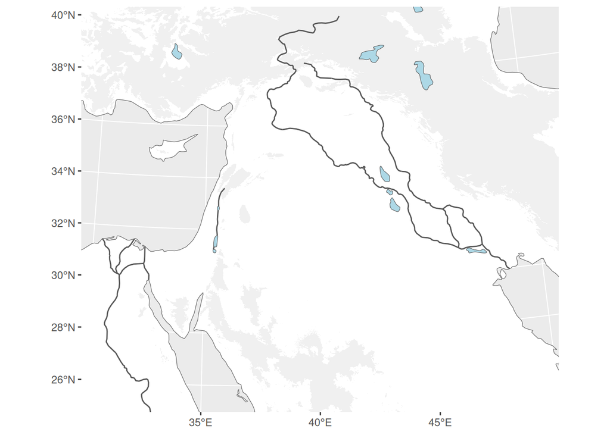

Figure 2.1: The study region

We aimed to collate archaeobotanical data from Southwest Asia (fig. 2.1) from the Neolithic period, c. 11,700 – 6500 BP (table 2.1). To mitigate against an “edge effect”, we also included samples in the source databases dated to the preceding Late Epipalaeolithic (c. 15,000–11,700 BP) and succeeding Chalcolithic (c. 6500–5000 BP).

Table 2.1: Cultural periods used in the analysis

| Period | Subsistence | Start (cal BP) | End (cal BP |
| --- | --- | --- | --- |
| Late Epipal. | Foraging | 15000 | 11700 |
| PPNA | Pre-domestication cultivation | 11700 | 10700 |
| EPPNB | Cultivation of domesticated species | 10700 | 10200 |
| MPPNB | Cultivation of domesticated species | 10200 | 9500 |
| LPPNB/C | Agriculture | 9500 | 8500 |
| Pottery Neolithic | Agriculture | 8500 | 6500 |
| Chalcolithic | Agriculture | 6500 | 5000 |

## 2.2 Archaeobotanical data (Southwest Asia)

We collated data from three large-scale archaeobotanical databases: ORIGINS (Wallace et al. 2018), and COMPAG Shennan and Conolly (2007), and ADEMNES (Riehl and Kümmel 2005). To clean and make these datasets comparable, we:

- Standardised site names across databases (thesaurus available at https://github.com/joeroe/swapdata);
- Standardised taxonomic names across databases and applied various additional classifications described below;
- When sites were in multiple databases, preferred records from the most detailed/recent one (i.e. ORIGINS > COMPAG > ADEMNES);
- ORIGINS is recorded by sample, but COMPAG and ADEMNES by phase, so aggregated ORIGINS by phase for comparability – and because individual samples are more likely to be ‘noisy’;
- Calculated phase-level proportions for COMPAG, which only includes absolute frequencies;
- Excluded records from the source databases that:
  - Were not taxonomically determined to at least the level of genus;
  - Did not actually contain quantitative information (i.e. `n` is blank or missing);
  - Described wood remains.

Finally we filtered this data to include only samples from our region (Southwest Asia) and period (11.7–6.5 ka cal BP) of interest, with a buffer of ±2,000 years to reduce “edge effects” in our time series analyses.

The resulting collated dataset (`analysis/data/derived_data/swasia_neolithic_flora.tsv`) includes archaeobotanical assemblages representing 240 distinct phases from 135 sites.

## 2.3 Archaeobotanical data (Europe)

We also used Colledge et al.’s (2004) compilation of European data (see also Shennan and Conolly 2007). Since this data did not need to be formally incorporated into the rest of the analyses, we simply imported Colledge et al.’s dataset as is, excluding non-European countries. It includes 268 assemblages from 211 Neolithic sites across Europe, but only presence data. For completeness, Cyprus was included in both the European and Southwest Asian datasets.

We used this data to quantitatively assess early evidence for translocation of certain crops from Southwest Asia to Europe, reported in table 3 of the main text.

## 2.4 Chronological data

All three databases include rough absolute date ranges (in the vast majority of cases summarised the available radiocarbon dates) for each sample. Using this data, each phase was classified into one of the cultural periods defined above using its mid-point date (table 2.2).

Table 2.2: Sites and assemblages per period

[output not shown]

For a finer-grained chronology, we also sliced the assemblages into century bins. An assemblage was considered to belong to a bin (e.g. 5000–5099 BP) if any part of its absolute date range falls within that bin – this results in the duplication of data across bins, but better reflects the inherent imprecision of radiocarbon dating.

## 2.5 Sample coverage

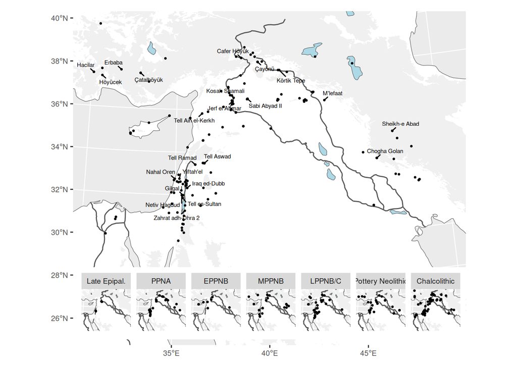

Figure 2.2: Geographical distribution of sampled archaeobotanical assemblages

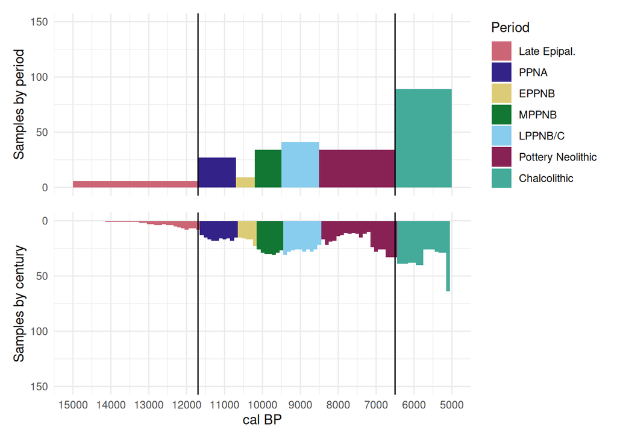

Figure 2.3: Distribution of sampled archaeobotanical assemblages by cultural period. Black lines indicate our period of interest (the Neolithic).

# 3 Results

## 3.1 Ubiquity of all taxa in the Neolithic

Table 3.1 summarises the occurrence of each standardised taxon across Neolithic assemblages, broken down by plant category.

Table 3.1: Ubiquity of all taxa across Neolithic assemblages. Founder crops are highlighted in bold.

| Taxa | N (%) recorded present | N (%) making up more than half of assemblage | N (%) making up more than a quarter of assemblage |
| --- | --- | --- | --- |
| Fruits/nuts |  |  |  |
| Pistacia spp. (incl. atlantica, lentiscus, palaestina, terebinthus, vera) | 92 (63.45%) | 2 (1.38%) | 7 (4.83%) |
| Ficus spp. (incl. carica) | 53 (36.55%) | 2 (1.38%) | 5 (3.45%) |
| Capparis spp. (incl. spinosa) | 29 (20.00%) | 0 | 0 |
| Amygdalus spp. (incl. communis, korshinskyi, webii) | 28 (19.31%) | 0 | 1 (0.69%) |
| Vitis spp. (incl. sylvestris, vinifera) | 17 (11.72%) | 0 | 0 |
| Crataegus spp. (incl. azarolus, monogyna) | 10 (6.90%) | 0 | 0 |
| Olea spp. (incl. europaea) | 10 (6.90%) | 0 | 0 |
| Prunus spp. (indeter) | 10 (6.90%) | 0 | 0 |
| Quercus spp. (incl. infectoria, ithaburensis) | 7 (4.83%) | 0 | 0 |
| Juglans regia | 2 (1.38%) | 0 | 0 |
| Punica spp. (incl. granatum) | 2 (1.38%) | 0 | 0 |
| Pyrus sp. | 2 (1.38%) | 0 | 0 |
| Rubus spp. (incl. caesius, fruticosus, idaeus, sanguineus) | 2 (1.38%) | 0 | 0 |
| Cupressus sempervirens | 1 (0.69%) | 0 | 0 |
| Phoenix spp. (incl. dactylifera, theophrasti) | 1 (0.69%) | 0 | 0 |
| Pinus halepensis | 1 (0.69%) | 0 | 0 |
| Prunus spp. (incl. microcarpa, spinosa, divariacata, argentea) | 1 (0.69%) | 0 | 0 |
| Rosa sp. | 1 (0.69%) | 0 | 0 |
| Vitex agnus-castus | 1 (0.69%) | 0 | 0 |
| Grasses |  |  |  |
| Hordeum spp. (spontaneum, distichum) | 124 (85.52%) | 5 (3.45%) | 13 (8.97%) |
| Triticum spp. (indeter. founder) | 77 (53.10%) | 16 (11.03%) | 26 (17.93%) |
| Triticum spp. (incl. dicoccoides/dicoccum) | 70 (48.28%) | 1 (0.69%) | 3 (2.07%) |
| Triticum spp. (indeter.) | 69 (47.59%) | 5 (3.45%) | 10 (6.90%) |
| Triticum spp. (incl. boeoticum/monococcum) | 61 (42.07%) | 1 (0.69%) | 4 (2.76%) |
| Bromus spp. (incl. arvensis, danthoniae, diandrus, hordeaceus, secalinus, sterilis, tectorum) | 59 (40.69%) | 0 | 0 |
| Lolium spp. (incl. perenne, persicum, remotum, rigidum, temulentum) | 59 (40.69%) | 0 | 5 (3.45%) |
| Aegilops spp. (incl. crassa, kotschyi, peregrina, speltoides, umbellulata) | 48 (33.10%) | 0 | 2 (1.38%) |
| Phalaris spp. (incl. minor, paradoxa, tuberosa) | 44 (30.34%) | 0 | 0 |

[output cut: 202 more lines]

This summary data underlies figure 5 in the main text.

## 3.2 Founder crop ubiquity and abundance

### 3.2.1 By period

Table 3.2 summarises the ubiquity of the founder crop species in assemblages broken down by period, i.e. for each period, it shows the number of assemblages where *N* distinct founder species are present, for varying values of *N*. Given the inconsistent levels of identification between assemblages, emmer wheat and einkorn wheat are counted as one crop. Hence, the maximum possible number of founder crops present is seven rather than eight.

Table 3.2: Ubiquity of the founder crops by period.

| Period | Total assemblages | Number of assemblages with N founder crops present: All | Number of assemblages with N founder crops present: >= 6 | Number of assemblages with N founder crops present: >= 5 | Number of assemblages with N founder crops present: >= 4 | Number of assemblages with N founder crops present: >= 3 | Number of assemblages with N founder crops present: >= 2 | Number of assemblages with N founder crops present: >= 1 |
| --- | --- | --- | --- | --- | --- | --- | --- | --- |
| Late Epipal. | 6 | 0 | 0 | 1 (16.67%) | 2 (33.33%) | 4 (66.67%) | 6 (100.00%) | 6 (100.00%) |
| PPNA | 27 | 0 | 0 | 2 (7.41%) | 7 (25.93%) | 15 (55.56%) | 16 (59.26%) | 25 (92.59%) |
| EPPNB | 9 | 0 | 2 (22.22%) | 4 (44.44%) | 7 (77.78%) | 9 (100.00%) | 9 (100.00%) | 9 (100.00%) |
| MPPNB | 34 | 1 (2.94%) | 3 (8.82%) | 5 (14.71%) | 11 (32.35%) | 25 (73.53%) | 32 (94.12%) | 34 (100.00%) |
| LPPNB/C | 41 | 1 (2.44%) | 6 (14.63%) | 8 (19.51%) | 20 (48.78%) | 29 (70.73%) | 35 (85.37%) | 39 (95.12%) |
| Pottery Neolithic | 34 | 1 (2.94%) | 5 (14.71%) | 9 (26.47%) | 13 (38.24%) | 22 (64.71%) | 30 (88.24%) | 33 (97.06%) |
| Chalcolithic | 89 | 0 | 2 (2.25%) | 6 (6.74%) | 15 (16.85%) | 25 (28.09%) | 66 (74.16%) | 83 (93.26%) |

### 3.2.2 By century

For a more fine-grained look at the time series, we can use the century bins calculated above. Figure 3.1 shows the importance of the individual founder crops measured by both cross-assemblage ubiquity and by relative abundance. We measure ubiquity by calculated the proportion of assemblages dated to each century where one or more, two or more, etc., of the founder crops were reported present; and abundance by the taking the mean proportion of the assemblage made up by each founder species for each century (hence NB., the y axis of the lower plot will not sum to 100%). These different measures reveal different trends, as discussed in the main text.

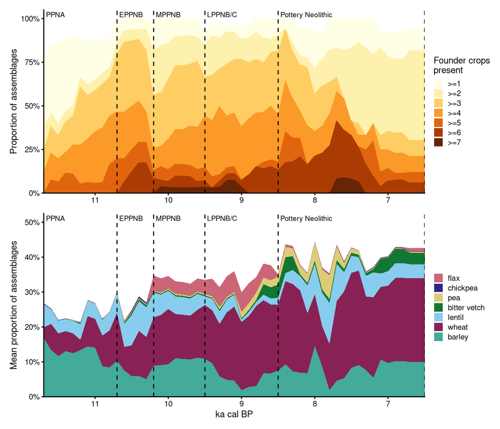

Figure 3.1: Ubiquity and abundance of the founder crops by century

## 3.3 Abundance of plant categories

To move beyond the concept of “founder crops” vs. “wild plants”, we classified each taxonomic record in our dataset on a number of other axes:

- Broad plant category, i.e. grasses, legumes, “wild plants”, or fruits/nuts
- Its edibility
- For grasses and legumes, whether it is large/medium- or small-seeded

Table 3.3: Abundance and ubiquity of broad plant categories across Neolithic assemblages.

| Category | Average proportion | Present | More than ½ | More than ¼ |
| --- | --- | --- | --- | --- |
| Grasses | 40.97% | 138 (95.17%) | 49 (33.79%) | 82 (56.55%) |
| Wild plants | 17.98% | 120 (82.76%) | 14 (9.66%) | 27 (18.62%) |
| Pulses | 13.40% | 125 (86.21%) | 6 (4.14%) | 20 (13.79%) |
| Fruits/nuts | 10.20% | 115 (79.31%) | 6 (4.14%) | 16 (11.03%) |
| Unclassified | 1.35% | 6 (4.14%) | 0 | 0 |

Table 3.4: Abundance and ubiquity of broad plant categories, by period.

| Category | Average proportion | Present | More than ½ | More than ¼ |
| --- | --- | --- | --- | --- |
| Late Epipal. |  |  |  |  |
| Wild plants | 38.31% | 6 (100.00%) | 2 (33.33%) | 4 (66.67%) |
| Grasses | 9.46% | 6 (100.00%) | 0 | 0 |
| Fruits/nuts | 7.77% | 6 (100.00%) | 0 | 1 (16.67%) |
| Pulses | 2.16% | 6 (100.00%) | 0 | 0 |
| Unclassified | 0.06% | 1 (16.67%) | 0 | 0 |
| PPNA |  |  |  |  |
| Grasses | 29.95% | 25 (92.59%) | 5 (18.52%) | 10 (37.04%) |
| Fruits/nuts | 18.70% | 21 (77.78%) | 2 (7.41%) | 7 (25.93%) |
| Wild plants | 14.15% | 20 (74.07%) | 1 (3.70%) | 3 (11.11%) |
| Pulses | 13.59% | 25 (92.59%) | 1 (3.70%) | 5 (18.52%) |
| Unclassified | 0.18% | 1 (3.70%) | 0 | 0 |
| EPPNB |  |  |  |  |
| Grasses | 41.34% | 9 (100.00%) | 2 (22.22%) | 7 (77.78%) |
| Pulses | 15.25% | 9 (100.00%) | 0 | 2 (22.22%) |
| Fruits/nuts | 7.79% | 9 (100.00%) | 0 | 1 (11.11%) |
| Wild plants | 6.61% | 8 (88.89%) | 0 | 0 |
| MPPNB |  |  |  |  |
| Grasses | 38.90% | 34 (100.00%) | 11 (32.35%) | 21 (61.76%) |
| Wild plants | 14.56% | 29 (85.29%) | 2 (5.88%) | 5 (14.71%) |
| Pulses | 11.95% | 32 (94.12%) | 0 | 3 (8.82%) |
| Fruits/nuts | 10.24% | 29 (85.29%) | 1 (2.94%) | 3 (8.82%) |
| Unclassified | 1.47% | 1 (2.94%) | 0 | 0 |
| LPPNB/C |  |  |  |  |
| Grasses | 42.43% | 37 (90.24%) | 15 (36.59%) | 24 (58.54%) |
| Wild plants | 21.86% | 38 (92.68%) | 5 (12.20%) | 11 (26.83%) |
| Pulses | 12.32% | 32 (78.05%) | 1 (2.44%) | 6 (14.63%) |
| Fruits/nuts | 7.94% | 33 (80.49%) | 2 (4.88%) | 4 (9.76%) |
| Unclassified | 1.61% | 4 (9.76%) | 0 | 0 |
| Pottery Neolithic |  |  |  |  |
| Grasses | 49.70% | 33 (97.06%) | 16 (47.06%) | 20 (58.82%) |
| Wild plants | 22.76% | 25 (73.53%) | 6 (17.65%) | 8 (23.53%) |
| Pulses | 15.61% | 27 (79.41%) | 4 (11.76%) | 4 (11.76%) |
| Fruits/nuts | 6.59% | 23 (67.65%) | 1 (2.94%) | 1 (2.94%) |
| Chalcolithic |  |  |  |  |
| Grasses | 49.53% | 86 (96.63%) | 43 (48.31%) | 64 (71.91%) |
| Pulses | 20.19% | 69 (77.53%) | 6 (6.74%) | 23 (25.84%) |
| Wild plants | 11.60% | 62 (69.66%) | 3 (3.37%) | 6 (6.74%) |
| Fruits/nuts | 7.39% | 26 (29.21%) | 0 | 2 (2.25%) |

Table 3.3 summarises the abundance of the broad plant categories across Neolithic assemblages, 3.4 the same data broken down by period, and figure 3.2 how this changed through time.

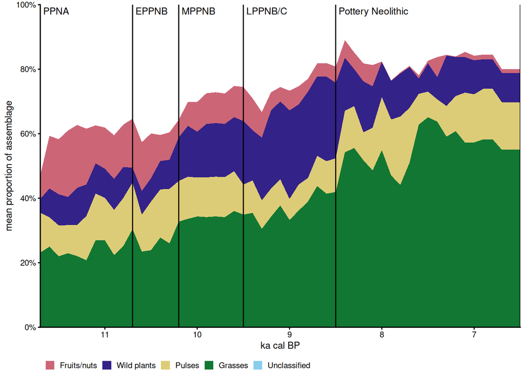

Figure 3.2: Abundance of broad plant categories through time

In the following sections, we will analyse trends within these categories in more detail.

### 3.3.1 Grasses

The eight most ubiquitous grass taxonomic groups, measured by presence across Neolithic assemblages, are: Hordeum spp. (spontaneum, distichum), Triticum spp. (indeter. founder), Triticum spp. (incl. boeoticum/monococcum), Triticum spp. (incl. dicoccoides/dicoccum), Triticum spp. (indeter.), Lolium spp. (incl. perenne, persicum, remotum, rigidum, temulentum), Bromus spp. (incl. arvensis, danthoniae, diandrus, hordeaceus, secalinus, sterilis, tectorum), Aegilops spp. (incl. crassa, kotschyi, peregrina, speltoides, umbellulata). Figure 3.3 shows how the abundance of these taxa changed through time.

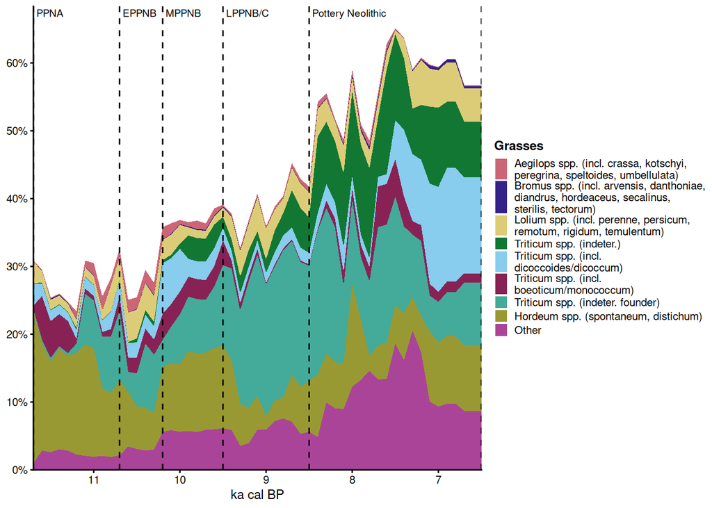

Figure 3.3: Abundance of grass taxa through time

### 3.3.2 Pulses

The eight most ubiquitous pulse taxonomic groups, measured by presence across Neolithic assemblages, are: Lens spp. (incl. culinaris, orientalis), Vicia sp. (indet.), Trigonella spp. (incl. arabica, astroites, noeana, sibthorpii), Medicago spp. (incl. laciniata, minima, orbicularis, polymorpha, radiata, truncatula), Pisum spp. (incl. elatius, sativum), Astragalus spp. (incl. annularis, callichrous, tribuloides, vogelii), Vicia ervilia, Lathryrus spp. (incl. aphaca, cicera, hirsutus, nissolia, sativus). Figure 3.4 shows how the abundance of these taxa changed through time.

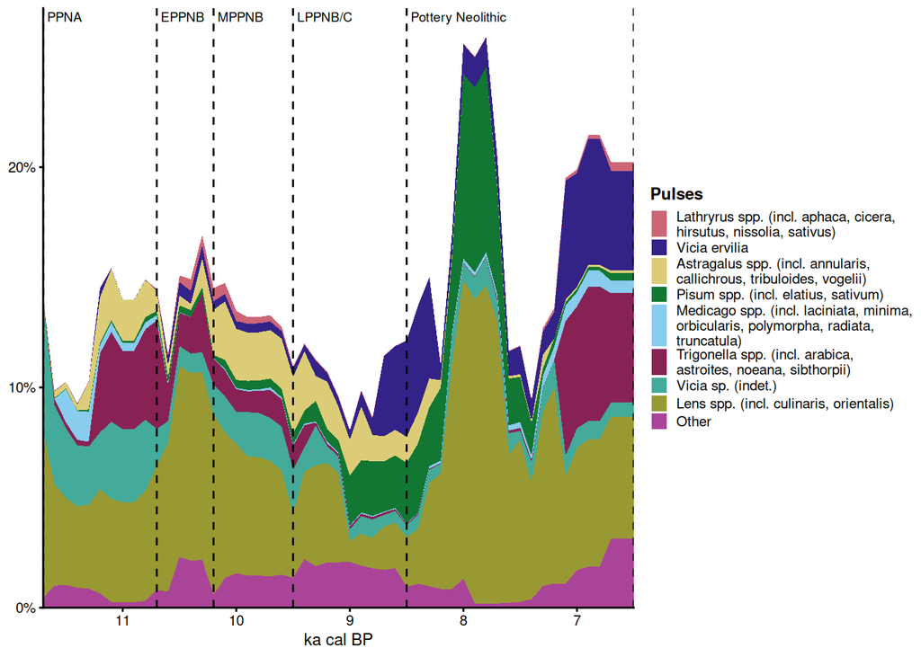

Figure 3.4: Abundance of pulse taxa through time

### 3.3.3 Wild plants

The eight most ubiquitous ‘wild plant’ taxonomic groups, measured by presence across Neolithic assemblages, are: Bolboschoenus spp. (incl. glaucus, maritimus), Buglossoides spp. (incl. arvensis, tenuiflora), Galium spp. (incl. aparine, mollugo, spurium, tricornotum, verrucosum), Malva spp. (incl. aegyptia, nicaeensis, parviflora, sylvestris), Brassicaceae indet. (edible), Arnebia spp. (incl. decumbens, linearifolia), Heliotropium spp. (incl. europaeum, persicum, rotundifolium, suaveolens), Silene spp. (incl. aegyptiaca, arabica, colorata, dichotoma, gallica). Figure 3.5 shows how the abundance of these taxa changed through time.

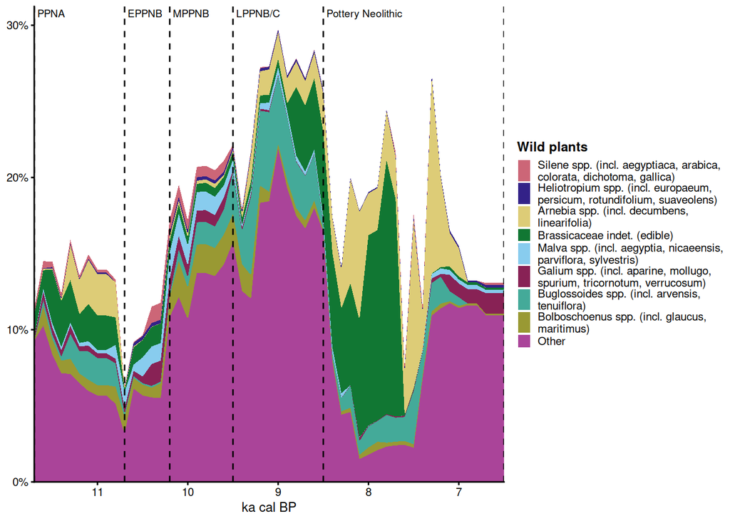

Figure 3.5: Abundance of wild plant taxa through time

### 3.3.4 Fruits and nuts

The eight most ubiquitous fruit/nut taxonomic groups, measured by presence across Neolithic assemblages, are: Pistacia spp. (incl. atlantica, lentiscus, palaestina, terebinthus, vera), Ficus spp. (incl. carica), Amygdalus spp. (incl. communis, korshinskyi, webii), Capparis spp. (incl. spinosa), Vitis spp. (incl. sylvestris, vinifera), Crataegus spp. (incl. azarolus, monogyna), Olea spp. (incl. europaea), Prunus spp. (indeter). Figure 3.6 shows how the abundance of these taxa changed through time.

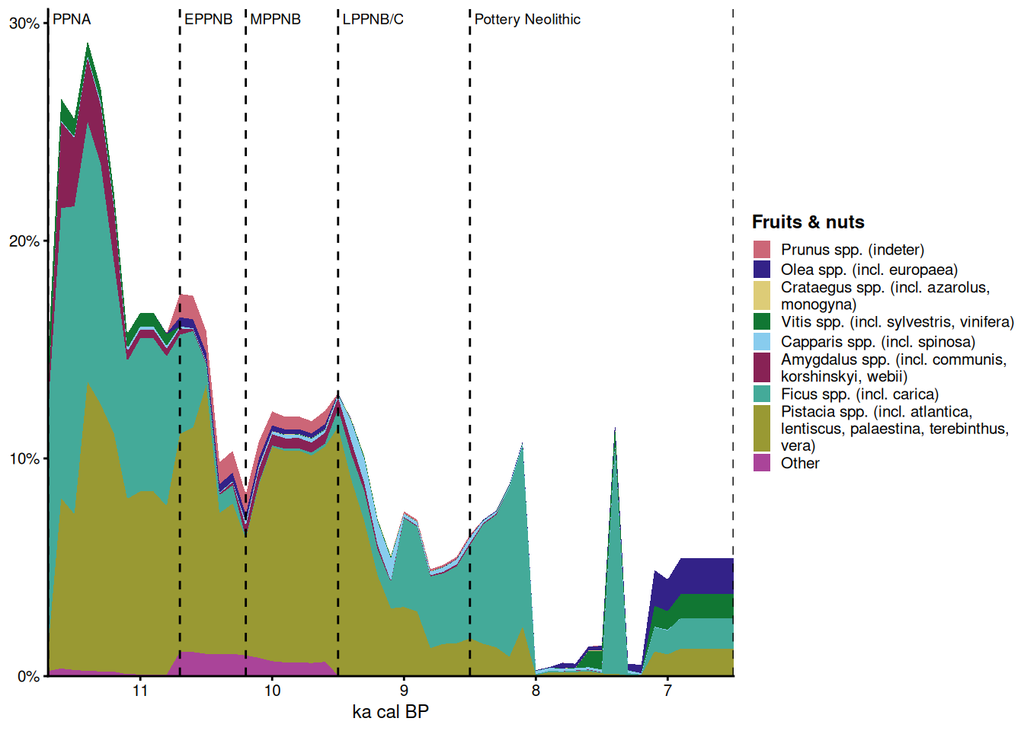

Figure 3.6: Abundance of fruit/nut taxa through time

# 4 References

Colledge, Sue, James Conolly, and Stephen Shennan. 2004. “Archaeobotanical Evidence for the Spread of Farming in the Eastern Mediterranean.” *Current Anthropology* 45 (S4): S35–58. https://doi.org/10.1086/422086.

Fuller, Dorian Q, Leilani Lucas, Lara González Carretero, and Chris Stevens. 2018. “Trends in Wild Food Use, Domestication and Cultivation Among Early Villages in Southwest Asia.” *Paléorient* 44 (2): 59–74. https://doi.org/10.2307/26595375.

Lucas, L, and D Fuller. 2018. “Dataset: From Intermediate Economies to Agriculture: Trends in Wild Food Use, Domestication and Cultivation Among Early Villages in Southwest Asia.” London, UK: UCL Institute of Archaeology. https://discovery.ucl.ac.uk/id/eprint/10052960/.

Riehl, Simone, and Christoph Kümmel. 2005. “Archaeobotanical Database of Eastern Mediterranean and Near Eastern Sites (ADEMNES).”

Shennan, Stephen J., and James Conolly. 2007. “Dataset: The Origin and Spread of Neolithic Plant Economies in the Near East and Europe.” Archaeology Data Service. https://doi.org/10.5284/1000093.

Wallace, Michael, Alexandra Livarda, Michael Charles, and Glynis Jones. 2018. “Origins of Agriculture: Archaeobotanical Database.” Archaeology Data Service. https://doi.org/10.5284/1046750.